# Phenotypic diversity analysis

Ruben Props & FM Kerckhof

2017-10-10

# 1 Install the package

Make sure to have the `devtools` package loaded.

```r
library(devtools)
install_github("rprops/Phenoflow_package")
```

# 2 Load the packages and source code

```r
library("Phenoflow") # for fingerprinting
library("flowViz") # for plotting
library("ggplot2") # for plotting
library("flowAI") # for denoising
```

Set a fixed seed to ensure reproducible analysis

```r
set.seed(777)
```

## 2.1 Load data

Load the test data or insert the path to your own data folder, for example test_data for the tutorial data.

```r
data(flowData)
#path = "test_data"
#flowData <- read.flowSet(path = path, transformation = FALSE, pattern=".fcs")
```

Lets first take a quick look at the dimensions of our flowData using the `attributes` function. Here we can see that we have 12 parameters (+ Width/Time) which we can use in our analyses.

```r
attributes(flowData)
```

```
## $frames
## <environment: 0x000000001d2832d8>
##
## $phenoData
## An object of class 'AnnotatedDataFrame'
##   rowNames: CYCLUS1_BEKKEN_-1_A_SYBR_PRECYCLE_rep1.fcs
##     CYCLUS1_BEKKEN_-3_A_SYBR_PRECYCLE_rep1.fcs ...
##     CYCLUS1_BEKKEN_9_A_SYBR_OPERATION_rep1.fcs (41 total)
##   varLabels: name
##   varMetadata: labelDescription
##
## $colnames
##  [1] "FSC-A" "SSC-A" "FL1-A" "FL2-A" "FL3-A" "FL4-A" "FSC-H" "SSC-H"
##  [9] "FL1-H" "FL2-H" "FL3-H" "FL4-H" "Width" "Time"
##
## $class
## [1] "flowSet"
## attr(,"package")
## [1] "flowCore"
```

## 2.2 Denoise data

Next, we select the phenotypic features of interest and transform their intensity values according to the hyperbolic arcsin. In this case we chose two fluorescent parameters and two scatter parameters in their height format (-H). Depending on the FCM, the resolution may increase by using the area values (-A) since many detectors have a higher signal resolution for area values. For transparency we store the transformed data in a new object, called `flowData_transformed`. We also define the parameters of interest (e.g. `c("FL1-H", "FL3-H","SSC-H","FSC-H")`)

```r
# Select phenotypic features of interest and transform parameters
flowData_transformed <- transform(flowData,`FL1-H`=asinh(`FL1-H`),
                                   `SSC-H`=asinh(`SSC-H`),
                                   `FL3-H`=asinh(`FL3-H`),
                                   `FSC-H`=asinh(`FSC-H`))
param=c("FL1-H", "FL3-H","SSC-H","FSC-H")
remove(flowData)
```

Now that the data has been formatted, we need to discard all the signals detected by the FCM which correspond to instrument noise and (in)organic background. This is done by selecting the cells in a scatterplot on the primary fluorescence or scatter signals. For SYBR Green I, this is done based on the `FL1-H` and `FL3-H` parameters. For this example, an initial polygon gate (`polyGate1`) is created and adjusted based on the sample type in question. For each specific experiment, it is advised to use identical gating for each sample. The gating strategy is evaluated on the `flowViz::xyplot` and adjusted if necessary. A more detailed guideline for gating or denoising aquatic microbial samples can be found [here](http://jornades.uab.cat/workshopmrama/sites/jornades.uab.cat.workshopmrama/files/Assessing_water_quality_with_the_BD_Accuri_C6_flow_cytometer.pdf) (p.6).

```r
### Create a PolygonGate for denoising the dataset
### Define coordinates for gate in sqrcut1 in format: c(x,x,x,x,y,y,y,y)
sqrcut1 <- matrix(c(8.75,8.75,14,14,3,7.5,14,3),ncol=2, nrow=4)
colnames(sqrcut1) <- c("FL1-H","FL3-H")
polyGate1 <- polygonGate(.gate=sqrcut1, filterId = "Total Cells")

###  Gating quality check
xyplot(`FL3-H` ~ `FL1-H`, data=flowData_transformed[1], filter=polyGate1,
       scales=list(y=list(limits=c(0,14)),
                   x=list(limits=c(6,16))),
       axis = axis.default, nbin=125,
       par.strip.text=list(col="white", font=2, cex=2), smooth=FALSE)
```

Here is an example of a good and bad filtering approach:

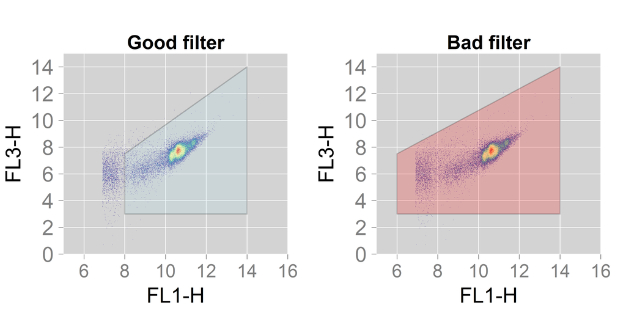

When the optimal gate has been chosen, the data can be denoised using the `Subset` function. Next we will gather some metadata from the sample names, which requires you have some pre-defined structured naming for your samples.

```r
### Isolate only the cellular information based on the polyGate1
flowData_transformed <- Subset(flowData_transformed, polyGate1)

### Extract metadata from sample names
metadata <- data.frame(do.call(rbind,
                               lapply(strsplit(flowCore::sampleNames(flowData),
                                               "_"), rbind)))
colnames(metadata) <- c("Cycle_nr", "Location", "day", "timepoint", "Staining",
                        "Reactor_phase", "replicate")
```

Next, the phenotypic intensity values of each cell are normalized to the [0,1] range. This is required for using a bandwidth of 0.01 in the fingerprint calculation. Each parameter is normalized based on the maximum FL1-H intensity value over the data set.

```r
summary <- fsApply(x = flowData_transformed, FUN = function(x) apply(x, 2, max),
                   use.exprs = TRUE)
maxval <- max(summary[,9])
mytrans <- function(x) x/maxval
flowData_transformed <- transform(flowData_transformed,`FL1-H`=mytrans(`FL1-H`),
                                  `FL3-H`=mytrans(`FL3-H`),
                                  `SSC-H`=mytrans(`SSC-H`),
                                  `FSC-H`=mytrans(`FSC-H`))
```

## 2.3 Fingerprinting

The denoised data can now be used for calculating the phenotypic fingerprint using the `flowBasis` function. Changing `nbin`increases the grid resolution of the density estimation but also steeply increases the computation time. The most determining factor for getting an accurate kernel density estimation is the number of cells counted in `polyGate1`. In general, 1,000 cells will give a good estimation of the mean alpha-diversity ($\text{D}_2$) but in order to reduce the variance on this estimate I would recommend a cell count of 10,000 cells or more. You can find more details [here](https://github.com/rprops/Phenoflow_package/wiki/Effect-of-sample-size%22). If desired, you can randomly resample your samples to the lowest sample size or any user specified sample size using the `FCS_resample()` function (standard without replacement, but can adjust by changing `replace`. Samples with a sample size that is equal to 0 or that is lower than the specified size will be discarded.

```r
### Randomly resample to the lowest sample size
#flowData_transformed <- FCS_resample(flowData_transformed, replace=TRUE)
### Calculate fingerprint with bw = 0.01
fbasis <- flowBasis(flowData_transformed, param, nbin=128,
                   bw=0.01,normalize=function(x) x)
```

The histogram below shows how the original distribution of sample sizes in our demo dataset was.

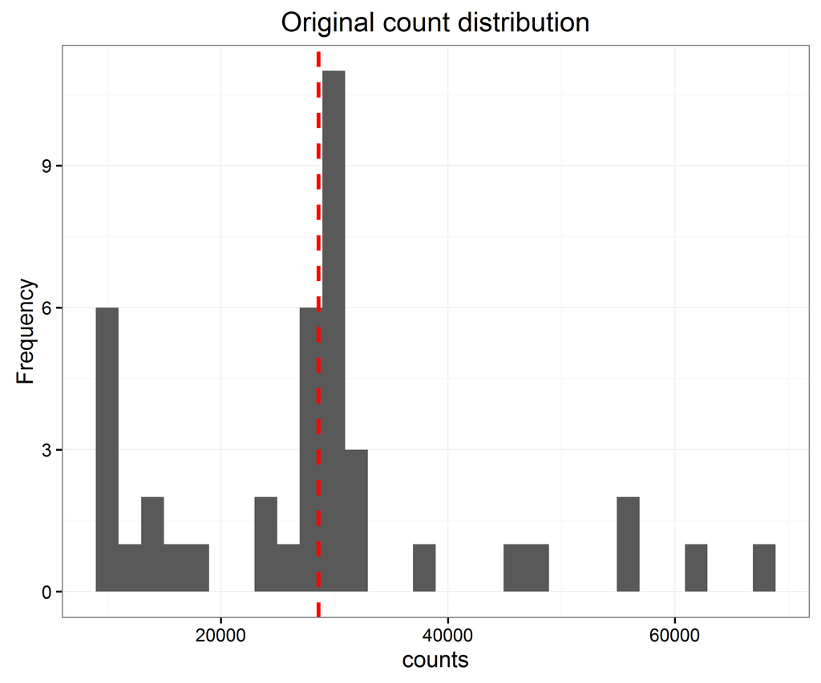

Subsampling to the lowest sampling size can be performed:

```r
fd_transformed <- FCS_resample(flowData_transformed, replace=TRUE)
```

```
## Your samples range between 9143 and 67033 cells
## Your samples were randomly subsampled to 9143 cells
```

## 2.4 Alpha diversity calculation

In this case we will continue with the samples without randomly subsampling. From the phenotypic fingerprint, alpha diversity metrics can be calculated.`n` is the number of technical replicates. Bootstrapping has been implemented for the Diversity function, so errors are calculated for each sample separately.  
`R` is the number of bootstraps. `d` is a rounding factor which is used to remove spurious density values from the dataset. Different rounding factors usually only scale the diversity estimates by a fixed factor and do not affect temporal trends or comparative analysis.

```r
### Calculate Diversity from normalized fingerprint
Diversity.fbasis <- Diversity(fbasis,d=3,plot=FALSE, R=999)
```

```
##  **Notice** As only frequency data is available, all bins will be resampled equally.
##           This is a conservative estimate of the error.
## Tue Oct 10 23:00:41 2017 ---- Alpha diversity metrics (D0,D1,D2) have been computed after 999 bootstraps
```

Add the argument `plot=TRUE` in case a quick plot of the ($\text{D}_2$) diversity values with their errors is desired. A bit more tidied up figure can be easily achieved as such:

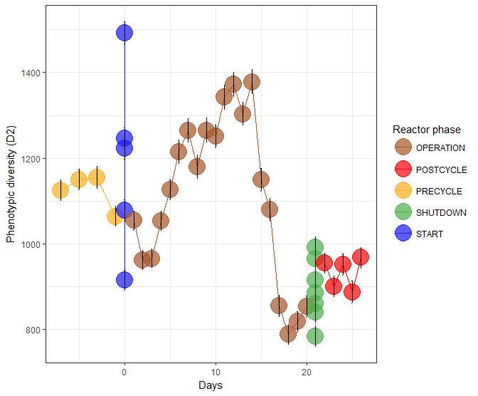

```r
p1 <- ggplot(data = Diversity.fbasis,
             aes(x = as.numeric(as.character(metadata$day)),
                 y = D2, color = metadata$Reactor_phase))+
      geom_point(size = 8, alpha = 0.7)+
      geom_line()+
      scale_color_manual(values = c("#a65628", "red", "#ffae19", "#4daf4a",
                                    "#1919ff", "darkorchid3", "magenta"))+
      theme_bw()+
      labs(color = "Reactor phase",
           y = "Phenotypic diversity (D2)",
           x = "Days")+
      geom_errorbar(aes(ymin=D2-sd.D2, ymax=D2+sd.D2), width=0.05,
                    color="black")
print(p1)
```

Typically for FCM data, the bootstrap replication results in an approximate normal distribution:

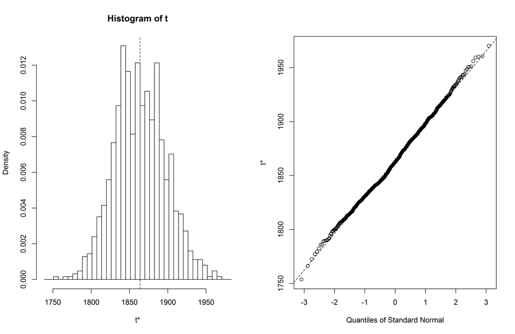

### 2.4.1 **Important:** `Diversity_rf` function

This function allows more accurate diversity and error estimation by bootstrapping from the initial FCS files, as well as denoising through [flowAI: automatic and interactive anomaly discerning tools for flow cytometry data](https://academic.oup.com/bioinformatics/article-lookup/doi/10.1093/bioinformatics/btw191). It can also easily be parallelized by setting `parallel = TRUE` and defining the number of cores with `ncores`. On Windows, you may have to give administrator permission the first time you try to parallelize (and have library `foreach` loaded). The input is a **non-subsetted** flowSet object (i.e. no parameters were removed - flowAI crashes otherwise) in case automated denoising is desired (`cleanFCS = TRUE`). Otherwise a normal subsetted flowSet object is enough. `R` is the number of bootstraps that should be taken from the initial FCS file, `R.b` is the number of bootstraps that should be taken from the fingerprint object.

```r
# Diversity assessment with cleaning
Diversity.clean <- Diversity_rf(flowData_transformed, param = param, R = 3,
                                R.b = 3,cleanFCS = TRUE)
```

```
## Tue Oct 10 23:00:44 2017 --- Using the following parameters for removing errant collection events
##  in samples with > 30,000 cells:
```

```
## [1] "flowClean detected no problems in test_data/CYCLUS1_BEKKEN_0_0h_SYBR_START_rep1.fcs."
```

```
## [1] "flowClean detected no problems in test_data/CYCLUS1_BEKKEN_0_10h_SYBR_START_rep1.fcs."
```

```
## [1] "flowClean detected no problems in test_data/CYCLUS1_BEKKEN_0_4h_SYBR_START_rep1.fcs."
```

```
## [1] "flowClean detected no problems in test_data/CYCLUS1_BEKKEN_0_6h_SYBR_START_rep1.fcs."
```

```
## [1] "flowClean detected no problems in test_data/CYCLUS1_BEKKEN_1_A_SYBR_OPERATION_rep1.fcs."
```

```
## [1] "flowClean detected no problems in test_data/CYCLUS1_BEKKEN_17_A_SYBR_OPERATION_rep1.fcs."
```

```
## [1] "flowClean detected no problems in test_data/CYCLUS1_BEKKEN_18_A_SYBR_OPERATION_rep1.fcs."
```

```
## [1] "flowClean detected no problems in test_data/CYCLUS1_BEKKEN_19_A_SYBR_OPERATION_rep1.fcs."
```

```
## [1] "flowClean detected no problems in test_data/CYCLUS1_BEKKEN_2_A_SYBR_OPERATION_rep1.fcs."
```

```
## [1] "flowClean detected no problems in test_data/CYCLUS1_BEKKEN_24_A_SYBR_POSTCYCLE_rep1.fcs."
```

```
## [1] "flowClean detected no problems in test_data/CYCLUS1_BEKKEN_25_A_SYBR_POSTCYCLE_rep1.fcs."
```

```
## [1] "flowClean detected no problems in test_data/CYCLUS1_BEKKEN_26_A_SYBR_POSTCYCLE_rep1.fcs."
```

```
## [1] "flowClean detected no problems in test_data/CYCLUS1_BEKKEN_3_A_SYBR_OPERATION_rep1.fcs."
```

```
## [1] "flowClean detected no problems in test_data/CYCLUS1_BEKKEN_4_A_SYBR_OPERATION_rep1.fcs."
```

```
## [1] "flowClean detected no problems in test_data/CYCLUS1_BEKKEN_5_A_SYBR_OPERATION_rep1.fcs."
## Tue Oct 10 23:06:36 2017 --- Done with cleaning data
## Tue Oct 10 23:06:36 2017 --- Starting resample run 1
## Tue Oct 10 23:06:52 2017 --- Starting resample run 2
## Tue Oct 10 23:07:08 2017 --- Starting resample run 3
## Tue Oct 10 23:07:23 2017 --- Alpha diversity metrics (D0,D1,D2) have been computed after 3 bootstraps
```

Similarly as before, we can plot these diversity calculations as well. Note that we only took 3 bootstraps here. It is recommended to increase `R` and `R.b` to 100.

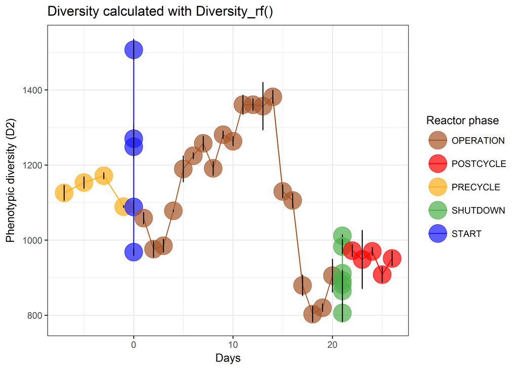

```r
p2 <- ggplot(data = Diversity.clean,
             aes(x = as.numeric(as.character(metadata$day)),
                 y = D2, color = metadata$Reactor_phase))+
  geom_point(size = 8, alpha = 0.7)+
  geom_line()+
  scale_color_manual(values = c("#a65628", "red",
                                "#ffae19", "#4daf4a", "#1919ff",
                                "darkorchid3", "magenta"))+
  theme_bw()+
  labs(color = "Reactor phase", y = "Phenotypic diversity (D2)", x = "Days")+
  geom_errorbar(aes(ymin=D2-sd.D2, ymax=D2+sd.D2), width=0.05, color="black")
print(p2)
```

Alpha diversity analysis has completed: time to export all the data to your working directory. If you are not sure where this is, type `getwd()`.

```r
### Export ecological data to .csv file in the chosen directory
names(Diversity.clean) <- paste0(names(Diversity.clean),".clean")
write.csv2(file="results.metrics.csv",
           cbind(Diversity.fbasis,Diversity.clean))
```

## 2.5 Beta diversity analysis

Optionally, you can also perform a beta diversity analysis using Non-metric Multidimensional Scaling (NMDS) or PCoA from the `vegan` package. The `beta_div_fcm` function does the calculation (accepts all dissimilarity metrics of the `vegdist` function under the `dist` argument) and the `plot_beta_fcm` plots the ordination. Additional factorial arguments to be given to the plot function are: `color` and `shape` which can be used for visualization (`color` and `shape` have to be factor vectors with length equal to number of samples). The title of the legends for these factors can be specified in the `labels` argument. In case no legend has to be displayed, `legend.pres` can be put to `FALSE`. **Attention: this dimension reduction utilizes the density values as opposed to the count values which are used for beta-diversity analysis in community 16S rRNA gene amplicon sequencing data sets**

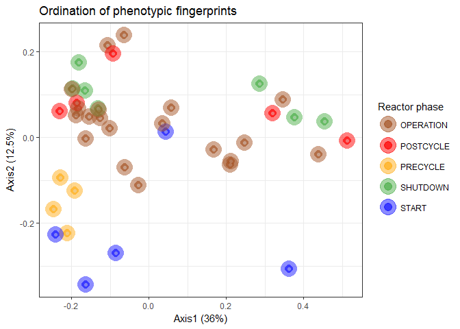

```r
# Beta-diversity assessment of fingerprint
set.seed(777)
beta.div <- beta_div_fcm(fbasis, ord.type="PCoA")

# Plot ordination
plot_beta_fcm(beta.div, color = metadata$Reactor_phase, labels="Reactor phase") +
  theme_bw() +
  geom_point(size = 8, alpha = 0.5)
```

## 2.6 Extract cell counts

It is often also useful to know the exact cell densities of your sample. This is performed by the following code. Additionally it quantifies the amount of High Nucleic Acid (HNA) and Low Nucleic Acid (LNA) bacteria as defined by [Prest et al. (2013)](http://www.sciencedirect.com/science/article/pii/S0043135413008361). Be aware that the `flowCore::filter` function has conflicts with the filter function from the `dplyr::filter` package (which is why we call them explicitely)

**Warning: the HNA/LNA partition is only valid for data gathered on a BD Accuri C6 flow cytometer.For other flow cytometers the HNA/LNA cutoff (FL1-H = 20 000) should be adjusted according to the appropriate reference samples.**

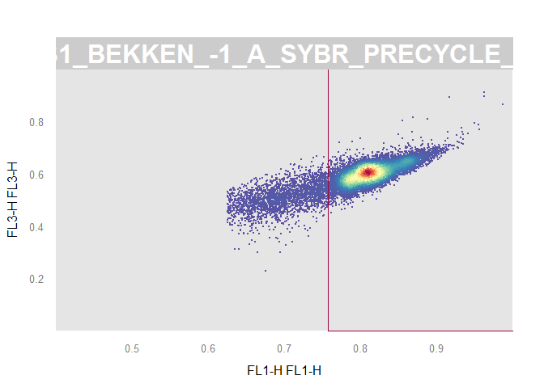

```r
### Creating a rectangle gate for counting HNA and LNA cells
rGate_HNA <- rectangleGate("FL1-H"=c(asinh(20000), 20)/maxval,
                           "FL3-H"=c(0,20)/maxval,
                           filterId = "HNA bacteria")
### Normalize total cell gate
sqrcut1 <- matrix(c(8.75,8.75,14,14,3,7.5,14,3)/maxval,ncol=2, nrow=4)
colnames(sqrcut1) <- c("FL1-H","FL3-H")
polyGate1 <- polygonGate(.gate=sqrcut1, filterId = "Total Cells")

### Check if rectangle gate is correct, if not, adjust rGate_HNA
xyplot(`FL3-H` ~ `FL1-H`, data=flowData_transformed[1], filter=rGate_HNA,
       scales=list(y=list(limits=c(0,1)),
                   x=list(limits=c(0.4,1))),
       axis = axis.default, nbin=125, par.strip.text=list(col="white", font=2,
                                                          cex=2), smooth=FALSE)
```

```r
### Extract the cell counts
a <- flowCore::filter(flowData_transformed, rGate_HNA)
HNACount <- summary(a);HNACount <- toTable(HNACount)
s <- flowCore::filter(flowData_transformed, polyGate1)
TotalCount <- summary(s);TotalCount <- toTable(TotalCount)

### Extract the volume
vol <- c()
for(i in 1:length(flowData_transformed)){
  vol[i] <- as.numeric(flowData_transformed[[i]]@description$`$VOL`)/1000
}

### Store the data
results_counts <- data.frame(Samples=flowCore::sampleNames(flowData_transformed),
                             Total.cells = TotalCount$true/vol,
                             HNA.cells = HNACount$true/vol)
```

Finally, you can export the count data if you so desire.

```r
### Exporting cell counts to .csv file to working directory
write.csv2(file="results.counts.csv", results_counts)
```

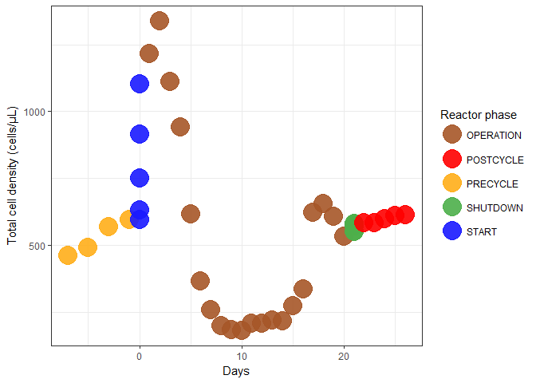

```r
### Plot cell density
ggplot(data = results_counts, aes(x = as.numeric(as.character(metadata$day)), y = Total.cells, color = metadata$Reactor_phase))+
  geom_point(size = 8, alpha = 0.9)+
  scale_color_manual(values = c("#a65628", "red",
                                "#ffae19", "#4daf4a", "#1919ff", "darkorchid3", "magenta"))+
  theme_bw()+
  labs(color = "Reactor phase", y = "Total cell density (cells/µL)", x = "Days")
```